# recurrent_nn

## 0. Device selection

```python
import torch

device = torch.device("cuda" if torch.cuda.is_available() else "cpu")
print(f"Using device: {device}")
```

```
Using device: cpu
```

## 1. Data preprocessing

```python
from functools import lru_cache

import numpy as np
import torch
from tensorflow.keras import preprocessing
from tensorflow.keras.datasets import imdb
from torch.utils.data import DataLoader


@lru_cache
def _download_data(
    vocab_size: int | None
) -> tuple[tuple[np.ndarray, np.ndarray], tuple[np.ndarray, np.ndarray]]:
    """Loads the IMDB dataset.

    docs (https://keras.io/api/datasets/imdb/):
    This is a dataset of 25,000 movies reviews from IMDB, labeled by sentiment
    (positive/negative). Reviews have been preprocessed, and each review is encoded as
    a list of word indexes (integers). For convenience, words are indexed by overall
    frequency in the dataset, so that for instance the integer "3" encodes the 3rd most
    frequent word in the data. This allows for quick filtering operations such as: "only
    consider the top 10,000 most common words, but eliminate the top 20 most common
    words".

    As a convention, "0" does not stand for a specific word, but instead is used to
    encode the pad token.

    Returns:
        Tuple of Numpy arrays: (x_train, y_train), (x_test, y_test).

        x_train, x_test: lists of sequences, which are lists of indexes (integers).
        If the num_words argument was specific, the maximum possible index value is
        num_words - 1. If the maxlen argument was specified, the largest possible
        sequence length is maxlen.

        y_train, y_test: lists of integer labels (1 or 0).
    """
    return imdb.load_data(path="data", num_words=vocab_size)


def get_data_loaders(
    batch_size: int,
    vocab_size: int | None = None,
    fraction_of_train_set: float = 1.0,
    max_seq_len: float | None = None,
    with_gpu: bool = False
) -> tuple[DataLoader, DataLoader, int]:
    """Gets train and validation DataLoaders along with the vocabulary size.

    If vocab_size is not specified it is assumed that all words from the dataset
    are used (88587 in IMDB dataset).

    Args:
        batch_size (int): Batch size for the DataLoader.
        vocab_size (int | None): Max size of the vocabulary. Defaults to None.
        fraction_of_train_set (float): Fraction of the train dataset used for the
            model's training.
        max_seq_len (int): Max length of the sequence (movie review), used for padding
            the sequences to the same length.

    Returns:
        tuple[DataLoader, DataLoader, int]: Tuple of train DataLoader, validation
            DataLoader and integer being a vocabulary size (88587 if vocab_size
            was not specified).
    """
    # data example: [[1, 43, 530, 973, 12...], [56, 33, 2, 18, 457...], ...]
    # labels example: [1 0 0 1 0 ...]
    (train_data, train_labels), (val_data, val_labels) = _download_data(vocab_size)

    # Calculate vocab_size if not specified
    if vocab_size is None:
        all_indices = [idx for seq in train_data + val_data for idx in seq]
        vocab_size = max(all_indices) + 1  # Add 1 for 0-based indexing

    max_seq_len_in_data = max(len(seq) for seq in train_data + val_data)
    if max_seq_len is None:
        max_seq_len = max_seq_len_in_data

    x_train: np.ndarray = preprocessing.sequence.pad_sequences(
        train_data, maxlen=max_seq_len
    )
    x_val: np.ndarray = preprocessing.sequence.pad_sequences(
        val_data, maxlen=max_seq_len
    )

    # Convert to tensors with float32 data type for the BCEWithLogitsLoss
    y_train: torch.Tensor = torch.tensor(train_labels, dtype=torch.float32)
    y_val: torch.Tensor = torch.tensor(val_labels, dtype=torch.float32)

    train_data = list(zip(x_train, y_train))
    val_data = list(zip(x_val, y_val))

    train_set_size = int(len(train_data) * fraction_of_train_set)
    train_data = train_data[:train_set_size]

    train_loader = DataLoader(
        train_data,
        batch_size=batch_size,
        shuffle=True,
        pin_memory=with_gpu
    )
    val_loader = DataLoader(
        val_data,
        batch_size=batch_size,
        shuffle=False,  # No need to shuffle the validation dataset
        pin_memory=with_gpu
    )

    return (train_loader, val_loader, vocab_size)
```

## 2. Data presentation tools

```python
import matplotlib.pyplot as plt

colors = ['#C7253E', '#0B2F9F', '#00712D']

def plot_metrics(results: list[dict[str, float]]):
    x = list(range(len(results)))
    accuracy = [results[i]['accuracy'] for i in x]
    recall = [results[i]['recall'] for i in x]
    f1 = [results[i]['f1'] for i in x]

    plt.figure(figsize=(8, 6))
    plt.plot(x, accuracy, linestyle='-', color=colors[0], label='Accuracy')
    plt.plot(x, recall, linestyle='-', color=colors[1], label='Recall')
    plt.plot(x, f1, linestyle='-', color=colors[2], label='F1 Score')

    plt.xlabel('Epoch')
    plt.ylabel('Metric score')
    plt.title('Plot of metric scores')

    plt.xlim(0, len(results))

    plt.legend()

    plt.grid(True)
    plt.show()


def plot_cost(results: list[dict[str, float]]):
    x = [i for i in range(len(results))]
    cost = [results[i]['cost'] for i in x]

    plt.figure(figsize=(8, 6))
    plt.plot(x, cost, linestyle='-', color=colors[0], label='Cost')

    plt.xlabel('Epoch')
    plt.ylabel('Cost function value')
    plt.title('Plot of cost value over time (epochs)')

    plt.xlim(0, len(results))

    plt.legend()

    plt.grid(True)
    plt.show()


def compare_plots(results_with_titles: list[tuple[dict, str]], cost: bool = False):
    count = len(results_with_titles)
    cols = min(count, 2)
    rows = ((count - 1) // 2) + 1

    fig, axs = plt.subplots(nrows=rows, ncols=cols, figsize=(12, 6), squeeze=False)

    for i in range(rows):
        for j in range(cols):
            plot_index = (2 * i) + j

            if plot_index < count:
                ax = axs[i, j]

                res, title = results_with_titles[plot_index]
                x = [k for k in range(len(res))]

                if cost:
                    cost = [res[j]['cost'] for j in x]
                    ax.plot(x, cost, linestyle='-', color=colors[0], label='Cost')
                else:
                    accuracy = [res[j]['accuracy'] for j in x]
                    recall = [res[j]['recall'] for j in x]
                    f1 = [res[j]['f1'] for j in x]

                    ax.plot(x, accuracy, linestyle='-', color=colors[0], label='Accuracy')
                    ax.plot(x, recall, linestyle='-', color=colors[1], label='Recall')
                    ax.plot(x, f1, linestyle='-', color=colors[2], label='F1 Score')

                ax.set_title(title)
                ax.set_xlim(0, len(res))
                ax.legend()
                ax.grid(True)
            else:
                axs[i, j].set_visible(False)

    fig.supxlabel('Epoch', fontsize=12)
    if cost:
        fig.supylabel('Cost function value', fontsize=12)
        fig.suptitle('Plot of cost value over time (epochs)', fontsize=14)
    else:
        fig.supylabel('Metric scores', fontsize=12)
        fig.suptitle('Plot of metric scores over time (epochs)', fontsize=14)

    plt.tight_layout()
    plt.subplots_adjust(top=0.9)
    plt.show()
```

## 3. Model

```python
from enum import Enum

import torch
import torch.nn as nn


class RNNType(Enum):
    RNN = 1
    LSTM = 2


class TextRNN(nn.Module):
    def __init__(
        self,
        vocab_size: int,
        embedding_dim: int,  # smaller - compact represent., larger - more expressive
        hidden_dim: int,
        output_dim: int,
        rnn_type: RNNType = RNNType.RNN,
        padding_idx: int = 0,  # By default 0 is used to encode the pad token
        num_layers: int = 1,
        bidirectional: bool = False,
        dropout: float = 0.5
    ):
        super().__init__()
        # Embedding layer to convert a list of indices to the word embeddings
        self.embedding = nn.Embedding(
            num_embeddings=vocab_size,
            embedding_dim=embedding_dim,
            padding_idx=padding_idx
        )

        # In both types we use batch_first=True, because then input and output tensors
        # are provided as (batch, seq, feature) instead of (seq, batch, feature).
        # Additionally we add a regularization if more than 1 RNN layer is used.
        if rnn_type == RNNType.LSTM:
            self.rnn = nn.LSTM(
                input_size=embedding_dim,
                hidden_size=hidden_dim,
                num_layers=num_layers,
                bidirectional=bidirectional,
                batch_first=True,
                dropout=dropout if num_layers > 1 else 0.0
            )
        elif rnn_type == RNNType.RNN:
            self.rnn = nn.RNN(
                input_size=embedding_dim,
                hidden_size=hidden_dim,
                num_layers=num_layers,
                bidirectional=bidirectional,
                batch_first=True,
                dropout=dropout if num_layers > 1 else 0.0
            )

        # If bidirectional is set to True then for each layer, we get two hidden states
        # (forward and backward). The final hidden state is concatenated, effectively
        # doubling the output dimension.
        rnn_output_dim = hidden_dim * (2 if bidirectional else 1)

        self.fc = nn.Linear(rnn_output_dim, output_dim)
        nn.init.xavier_uniform_(self.fc.weight)
        nn.init.zeros_(self.fc.bias)

        # Note! No activation function is used because BCEWithLogitsLoss already
        # contains internal Sigmoid layer which is more numerically stable.


    def forward(self, batch):
        # batch shape: (batch_size, sequence_length), e.g. [32, 20]
        embedded = self.embedding(batch)
        # embedded shape: (batch_size, sequence_length, embedding_dim)

        # We don't need the final forward and reverse hidden states so we skip them '_'
        rnn_out, _ = self.rnn(embedded)
        # rnn_out shape: (batch_size, sequence_length, hidden_dim)

        # WE USE MANY-TO-ONE architecture so we only need the last time step
        final_features = rnn_out[:, -1, :]
        # final_features shape: (batch_size, hidden_dim)

        output = self.fc(final_features)
        # output shape: (batch_size, output_dim)

        if self.fc.out_features == 1:
            output = output.squeeze()
            # output shape: (batch_size)

        return output
```

## 4. Training

```python
import time

from sklearn.metrics import accuracy_score, f1_score, recall_score
from torch.nn.modules import Module
from torch.optim.optimizer import Optimizer
from torch.utils.data import DataLoader


def add_noise_to_batch(batch, noise_std):
    if noise_std > 0.0:
        noise = torch.randn_like(batch) * noise_std
        noisy_batch = batch + noise
        return torch.clamp(noisy_batch, 0, 1)
    return batch


def train_one_epoch(
    model: TextRNN,
    train_loader: DataLoader,
    loss_fn: Module,
    optimizer: Optimizer,
    device: torch.device,
    train_noise_std: float = 0.0
):
    model.to(device)
    for X, y in train_loader:
        X = add_noise_to_batch(X, train_noise_std)

        X, y = X.to(device), y.to(device)
        # Zero gradients for every batch!
        optimizer.zero_grad()

        # Make predictions for this batch
        y_pred = model(X)

        # Compute the loss and its gradients
        loss = loss_fn(y_pred, y)
        loss.backward()

        # Adjust learning weights
        optimizer.step()


def train_model(
    model: TextRNN,
    max_epochs: int,
    train_loader: DataLoader,
    val_loader: DataLoader,
    loss_fn: Module,
    optimizer: Optimizer,
    device: torch.device,
    train_noise_std: float = 0.0,
    val_noise_std: float = 0.0,
    debug: bool = False
):
    model.to(device)
    results = []
    prev_avg_val_loss = 0.0
    start = time.time()
    # Initialize training
    for epoch in range(max_epochs):
        elapsed_time = int(time.time() - start)
        print(f"{elapsed_time}s [{epoch + 1}/{max_epochs}] Epoch with {device} device")
        model.train()  # Set model to training mode

        # Train for one epoch
        train_one_epoch(
            model=model,
            train_loader=train_loader,
            loss_fn=loss_fn,
            optimizer=optimizer,
            device=device,
            train_noise_std=train_noise_std
        )

        model.eval()
        running_val_loss = 0.0
        all_labels = []
        all_preds = []

        with torch.no_grad():
            for X, y in val_loader:
                X = add_noise_to_batch(X, val_noise_std)

                X, y = X.to(device), y.to(device)
                y_pred = model(X)
                val_loss = loss_fn(y_pred, y)
                running_val_loss += val_loss.item()

                predicted_classes = (torch.sigmoid(y_pred) > 0.5).float()
                all_labels.extend(y.cpu().numpy())
                all_preds.extend(predicted_classes.cpu().numpy())

        # Calculate metrics for the epoch
        accuracy = accuracy_score(all_labels, all_preds)
        recall = recall_score(all_labels, all_preds, average='weighted')
        f1 = f1_score(all_labels, all_preds, average='weighted')
        avg_val_loss = running_val_loss / len(val_loader)

        results.append({
            "accuracy": accuracy,
            "recall": recall,
            "f1": f1,
            "cost": avg_val_loss
        })

        delta = avg_val_loss - prev_avg_val_loss
        if debug:
            print(f"Epoch [{epoch+1}/{max_epochs}] - avg val loss: {avg_val_loss:.4f} (delta: {delta})")
        prev_avg_val_loss = avg_val_loss

    print("Training complete!")
    return results
```

## 5. Experiments

```python
from typing import Any

BATCH_SIZE = 64  # arbitraly chosen batch size, balance between computation and memory
DROPOUT = 0.2  # arbitraly chosen regularization factor
MAX_EPOCHS = 12

def run_experiment(
    param_config: dict[str, Any],
    device: torch.device,
):
    vocabulary_size: int | None = param_config["vocabulary_size"]
    rnn_type: RNNType = param_config["rnn_type"]
    hidden_dim: int = param_config["hidden_dim"]
    max_seq_len: int | None = param_config["max_seq_len"]
    embedding_dim: int | None = param_config["embedding_dim"]
    bidirectional: bool = param_config["bidirectional"]

    train_loader, val_loader, vocab_size = get_data_loaders(
        batch_size=BATCH_SIZE,
        vocab_size=vocabulary_size,
        max_seq_len=max_seq_len,
        with_gpu=(device.type == "cuda"),
    )

    model = TextRNN(
        vocab_size=vocab_size,
        embedding_dim=embedding_dim,
        hidden_dim=hidden_dim,
        output_dim=1,
        rnn_type=rnn_type,
        bidirectional=bidirectional,
        dropout=DROPOUT
    )

    optimizer = torch.optim.Adam(model.parameters())
    results = train_model(
        model=model,
        max_epochs=MAX_EPOCHS,
        train_loader=train_loader,
        val_loader=val_loader,
        loss_fn=nn.BCEWithLogitsLoss(),
        optimizer=optimizer,
        device=device
    )

    return results
```

```python
import itertools


def grid_search(param_grid: dict[str, list[Any]]):
    device = torch.device("cuda") if torch.cuda.is_available() else torch.device("cpu")

    keys, values = zip(*param_grid.items())
    param_combinations = [dict(zip(keys, v)) for v in itertools.product(*values)]

    for i, param_config in enumerate(param_combinations, 1):
        print(f"Running experiment {i}/{len(param_combinations)}")
        with open("results.txt", "a") as f:
            experiment_results = run_experiment(param_config, device)

            f.write(f"Experiment {i}:\n")
            f.write("Parameters:\n")
            for key, value in param_config.items():
                f.write(f"  {key}: {value}\n")
            f.write("Results:\n")
            f.write(str(experiment_results))
            f.write("\n" + "-" * 50 + "\n")
```

```python
param_grid_1 = {
    "vocabulary_size": [8000, 44000, None],
    "rnn_type": [RNNType.LSTM],
    "hidden_dim": [64],
    "max_seq_len": [None],
    "embedding_dim": [32],
    "bidirectional": [True]
}
param_grid_2 = {
    "vocabulary_size": [10000],
    "rnn_type": [RNNType.RNN, RNNType.LSTM],
    "hidden_dim": [32, 64, 128],
    "max_seq_len": [10, 20, None],
    "embedding_dim": [16, 32, 64],
    "bidirectional": [True, False]
}

grid_search(param_grid_1)
grid_search(param_grid_2)
```

## 6. Results

The experiments were run in the Google Colab environment on a GPU.  
It took almost 2 hours to run all 111 test cases.  
All results were saved to a .txt file and then analysed locally.

##### First observations

The hyperparameter configuration had a huge impact on the time needed to run a training. For example, one of the longest experiments took almost 12 minutes with the following parameters

- vocabulary_size: 10000
- rnn_type: RNNType.LSTM
- hidden_dim: 128
- max_seq_len: None
- embedding_dim: 64
- bidirectional: True

while some experiments (like the one below) took less than 20 seconds to complete (12 epochs in each test case). This one, for example, only differs in `max_seq_len` (fixed to 20) and `bidirectional` (False instead of True):

- vocabulary_size: 10000
- rnn_type: RNNType.LSTM
- hidden_dim: 128
- max_seq_len: 20
- embedding_dim: 64
- bidirectional: False

```python
import ast
from dataclasses import dataclass
from functools import lru_cache
from pathlib import Path


@dataclass
class ParamsConfig:
    vocabulary_size: int | None
    rnn_type: RNNType
    hidden_dim: int
    max_seq_len: int | None
    embedding_dim: int
    bidirectional: bool


@dataclass
class Results:
    params_config: ParamsConfig
    results: list[dict[str, float]]


@lru_cache
def parse_results_file(file_path: Path) -> list[Results]:
    with open(file_path) as f:
        lines = f.readlines()

    all_results = []

    i = 0
    while i < len(lines):
        if lines[i].startswith("Experiment"):
            params = {}
            while i < len(lines) and not lines[i].startswith("Results:"):
                if ":" in lines[i]:
                    key, value = lines[i].split(":", 1)
                    key = key.strip()
                    value = value.strip()
                    if key in ["vocabulary_size", "max_seq_len"]:
                        params[key] = None if value == "None" else int(value)
                    elif key == "rnn_type":
                        if value == "RNNType.LSTM":
                            params[key] = RNNType.LSTM
                        else:
                            params[key] = RNNType.RNN
                    elif key in ["hidden_dim", "embedding_dim"]:
                        params[key] = int(value)
                    elif key == "bidirectional":
                        params[key] = True if value == "True" else False
                i += 1
            if lines[i].startswith("Results:"):
                i += 1
                results = ast.literal_eval(lines[i])
            else:
                results = None

            params_config = ParamsConfig(**params)
            all_results.append(Results(
                params_config=params_config,
                results=results
            ))
        i += 1

    return all_results
```

```python
all_results = parse_results_file(
    file_path = Path("colab_results.txt")
)


def filter_results(**kwargs) -> Results | None:
    for res in all_results:
        flag = 1
        for key, val in kwargs.items():
            if not getattr(res.params_config, key) == val:
                flag *= 0
        if flag == 1:
            return res
    return None
```

### Vocabulary size (10% vs 50% vs 100%)

Fixed hyperparameters:

- recurrent layer type: bidirectional LSTM
- recurrent layer hidden_dim: 64
- max_seq_len: None (no sequence cutting)
- embedding_dim: 32

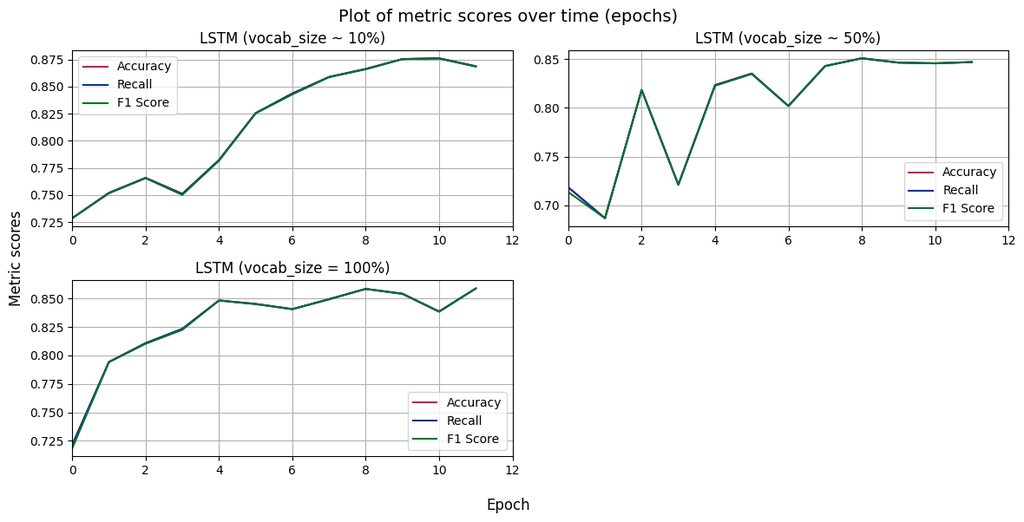

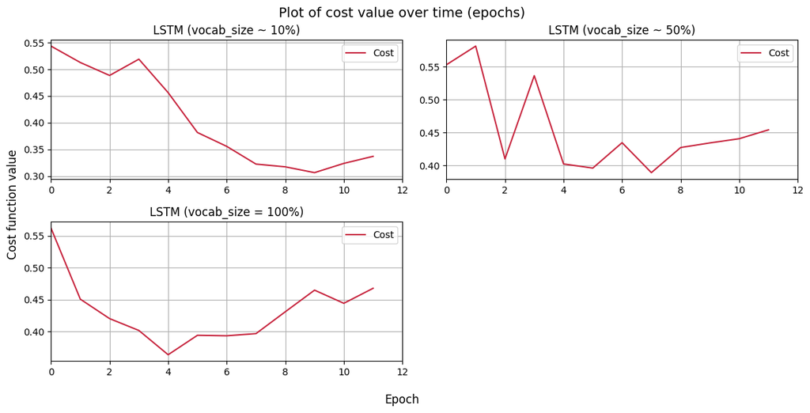

```python
results_1 = filter_results(
    vocabulary_size=8000,
    rnn_type=RNNType.LSTM,
    hidden_dim=64,
    max_seq_len=None,
    embedding_dim=32,
    bidirectional=True
)
results_2 = filter_results(
    vocabulary_size=44000,
    rnn_type=RNNType.LSTM,
    hidden_dim=64,
    max_seq_len=None,
    embedding_dim=32,
    bidirectional=True
)
results_3 = filter_results(
    vocabulary_size=None,
    rnn_type=RNNType.LSTM,
    hidden_dim=64,
    max_seq_len=None,
    embedding_dim=32,
    bidirectional=True
)


results_with_titles = [
    (results_1.results, "LSTM (vocab_size ~ 10%)"),
    (results_2.results, "LSTM (vocab_size ~ 50%)"),
    (results_3.results, "LSTM (vocab_size = 100%)"),
]

compare_plots(results_with_titles)
compare_plots(results_with_titles, cost=True)
```

##### Analysis

The above experiment shows that increasing the size of the vocabulary can have a negative impact on the performance of the model. With `vocab_size=100%` the model achieved quite high metric values, but overfitting already occurred in the 4th epoch. This is because the model was learning patterns from all possible words that were present, even if they only appeared once or twice. Seeing the same word in the validation data could then lead to incorrect sentiment labelling.

Overall, the plots suggest that it is important to train the model using only a subset of the total vocabulary (not randomly selected, but using a percentage of the most popular words). In this way, the model can generalise the text more by learning the patterns between the most popular words. Focusing the model on the most common and informative words is a key aspect in this case.

### Bidirectionality

Fixed hyperparameters:

- recurrent layer type: LSTM
- recurrent layer hidden_dim: 128
- max_seq_len: None (no sequence cutting)
- embedding_dim: 64

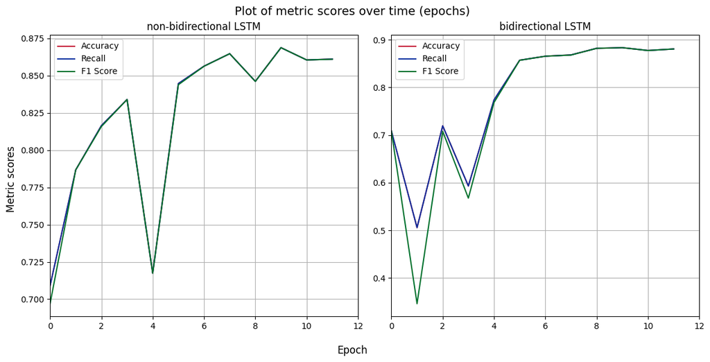

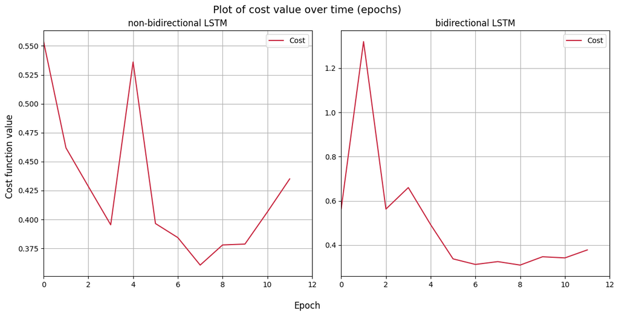

```python
results_1 = filter_results(
    vocabulary_size=10000,
    rnn_type=RNNType.LSTM,
    hidden_dim=128,
    max_seq_len=None,
    embedding_dim=64,
    bidirectional=False
)
results_2 = filter_results(
    vocabulary_size=10000,
    rnn_type=RNNType.LSTM,
    hidden_dim=128,
    max_seq_len=None,
    embedding_dim=64,
    bidirectional=True
)


results_with_titles = [
    (results_1.results, "non-bidirectional LSTM"),
    (results_2.results, "bidirectional LSTM"),
]

compare_plots(results_with_titles)
compare_plots(results_with_titles, cost=True)
```

##### Analysis

This experiment compares the performance of bidirectional and non-bidirectional LSTM recurrent networks. There is not much difference in terms of metrics, but we can observe that the bidirectional LSTM recurrent network is more stable and resilient to overfitting (which is clearly present in the non-bidirectional network).

This type of task (sentiment analysis of IMDB movie reviews) may not necessarily benefit much from the bidirectional nature of an LSTM model, as the sentiment of a review can often be inferred from the words and patterns present in the text, without the need for strong backward dependencies. However, for the reasons described in the first paragraph, the bidirectional network was used in the following experiments.

### Embedding dimension (16 vs 32 vs 64)

Fixed hyperparameters:

- recurrent layer type: bidirectional LSTM
- recurrent layer hidden_dim: 128
- max_seq_len: None (no sequence cutting)

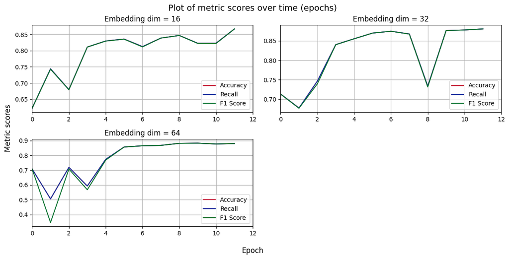

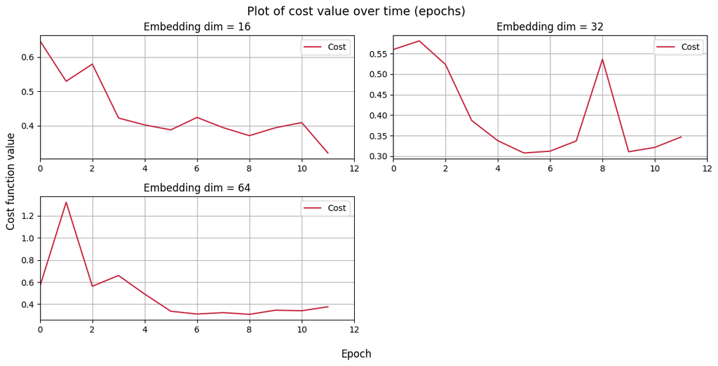

```python
results_1 = filter_results(
    vocabulary_size=10000,
    rnn_type=RNNType.LSTM,
    hidden_dim=128,
    max_seq_len=None,
    embedding_dim=16,
    bidirectional=True
)
results_2 = filter_results(
    vocabulary_size=10000,
    rnn_type=RNNType.LSTM,
    hidden_dim=128,
    max_seq_len=None,
    embedding_dim=32,
    bidirectional=True
)
results_3 = filter_results(
    vocabulary_size=10000,
    rnn_type=RNNType.LSTM,
    hidden_dim=128,
    max_seq_len=None,
    embedding_dim=64,
    bidirectional=True
)


results_with_titles = [
    (results_1.results, "Embedding dim = 16"),
    (results_2.results, "Embedding dim = 32"),
    (results_3.results, "Embedding dim = 64"),
]

compare_plots(results_with_titles)
compare_plots(results_with_titles, cost=True)
```

##### Analysis

This experiment compares the model performance with 3 different embedding layer dimensions (16, 32 and 64). Increasing the embedding dimension from 16 to 32 to 64 generally improves the model's performance on the core evaluation metrics. This increase was accompanied by greater stability.

In general, a higher embedding dimension means that the model is able to extract more features from the data, but this is often accompanied by a higher risk of overfitting. In this case, however, the model with `embedding_dim=64` seems to be quite well trained and stable with some minimal symptoms of overfitting, so this value was used in the next experiments (thanks to its stability, this model could become a baseline for further tests).

We can also see that the model with `embedding_dim=16` performed very promisingly at the end of training, but it was not as stable and more epochs would be needed to verify its performance.

### Recurrent layer type (RNN vs LSTM)

Fixed hyperparameters:

- recurrent layer hidden_dim: 128
- max_seq_len: None (no sequence cutting)
- embedding_dim: 64
- recurrent layer bidirectionality: bidirectional

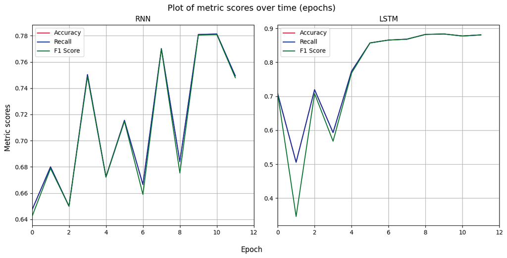

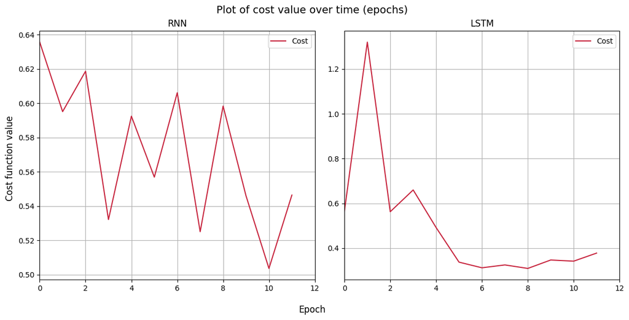

```python
results_1 = filter_results(
    vocabulary_size=10000,
    rnn_type=RNNType.RNN,
    hidden_dim=128,
    max_seq_len=None,
    embedding_dim=64,
    bidirectional=True
)
results_2 = filter_results(
    vocabulary_size=10000,
    rnn_type=RNNType.LSTM,
    hidden_dim=128,
    max_seq_len=None,
    embedding_dim=64,
    bidirectional=True
)


results_with_titles = [
    (results_1.results, "RNN"),
    (results_2.results, "LSTM"),
]

compare_plots(results_with_titles)
compare_plots(results_with_titles, cost=True)
```

#### Analysis

These experiments show that the LSTM architecture significantly outperforms the standard RNN for this particular text processing task. The model with the LSTM recurrent layer has the ability to better capture long-term dependencies and contextual information in the text data, which allows it to learn more effective representations. This results in much higher evaluation metric scores and a lower cost function. LSTM is the more appropriate choice for this type of text semantic labelling problem and therefore it was used in the next experiments.

### Recurrent layer dimension

Fixed hyperparameters:

- recurrent layer type: bidirectional LSTM
- max_seq_len: None (no sequence cutting)
- embedding_dim: 64
- recurrent layer bidirectionality: bidirectional

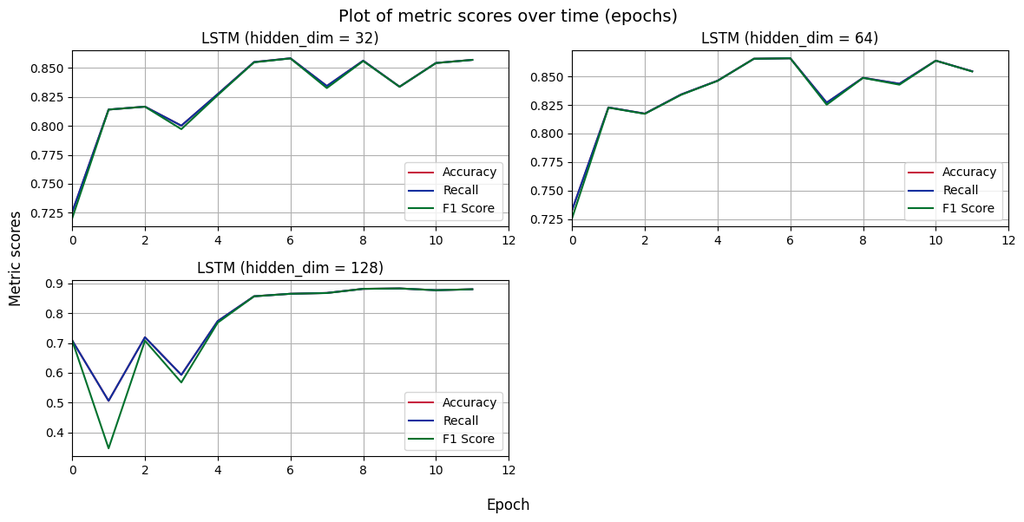

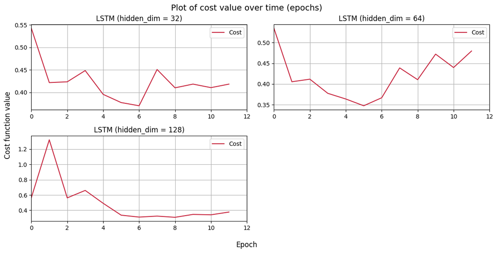

```python
results_1 = filter_results(
    vocabulary_size=10000,
    rnn_type=RNNType.LSTM,
    hidden_dim=32,
    max_seq_len=None,
    embedding_dim=64,
    bidirectional=True
)
results_2 = filter_results(
    vocabulary_size=10000,
    rnn_type=RNNType.LSTM,
    hidden_dim=64,
    max_seq_len=None,
    embedding_dim=64,
    bidirectional=True
)
results_3 = filter_results(
    vocabulary_size=10000,
    rnn_type=RNNType.LSTM,
    hidden_dim=128,
    max_seq_len=None,
    embedding_dim=64,
    bidirectional=True
)


results_with_titles = [
    (results_1.results, "LSTM (hidden_dim = 32)"),
    (results_2.results, "LSTM (hidden_dim = 64)"),
    (results_3.results, "LSTM (hidden_dim = 128)"),
]

compare_plots(results_with_titles)
compare_plots(results_with_titles, cost=True)
```

#### Analysis

In this experiment we can see a comparison between models with different hidden dimensions of the LSTM layer (32 vs 64 vs 128). Generally speaking, higher dimension in this case means that the model has more parameters and capacity to learn complex patterns and representations from the input data, but it comes with some trade-offs, mainly a computational complexity.

Both 3 models performed quite well, but again - the model with the highest hyperparameter value won in this case and showed the most stable performance. Two other models achieved a similar level of metrics and cost, but were much more volatile and started to show some overfitting symptoms much faster than the model with `hidden_dim=128`.

### Max sequence length / padding (10 vs 20 vs no limit)

Fixed hyperparameters:

- recurrent layer type: bidirectional LSTM
- recurrent layer hidden_dim: 128
- embedding_dim: 64

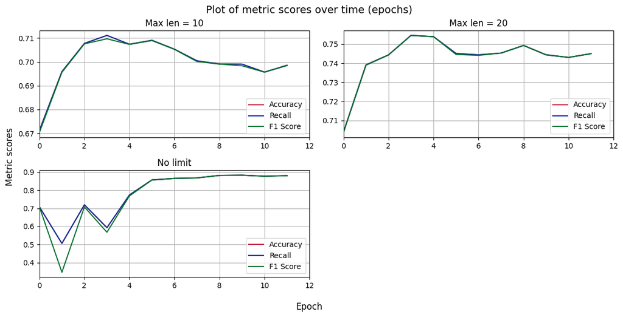

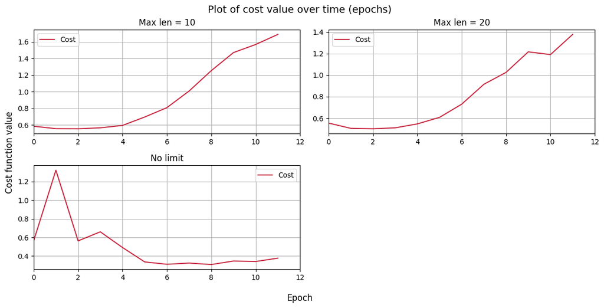

```python
results_1 = filter_results(
    vocabulary_size=10000,
    rnn_type=RNNType.LSTM,
    hidden_dim=128,
    max_seq_len=10,
    embedding_dim=64,
    bidirectional=True
)
results_2 = filter_results(
    vocabulary_size=10000,
    rnn_type=RNNType.LSTM,
    hidden_dim=128,
    max_seq_len=20,
    embedding_dim=64,
    bidirectional=True
)
results_3 = filter_results(
    vocabulary_size=10000,
    rnn_type=RNNType.LSTM,
    hidden_dim=128,
    max_seq_len=None,
    embedding_dim=64,
    bidirectional=True
)


results_with_titles = [
    (results_1.results, "Max len = 10"),
    (results_2.results, "Max len = 20"),
    (results_3.results, "No limit"),
]

compare_plots(results_with_titles)
compare_plots(results_with_titles, cost=True)
```

#### Analysis

The last experiment focused on the influence of the maximum sentence length and the padding on the model performance. 3 scenarios were tested: the first with truncation to 10 words, the second with truncation to 20 words and the third without truncation. The results clearly show that such a technique has a negative impact on the performance of the model. This is probably due to the fact that if all film reviews are truncated to 10 or 20 words, then many keywords and sub-sentences may have been lost and the model cannot learn all the connections because it has to learn to predict the semantic label based on the first 10/20 words of the review, which may be very inaccurate. The model without this limitation performed best, as it had the opportunity to learn some patterns correctly from the input batches.